# duolingo_take_home_project

## Overview

This is a take home project for Duolingo. The data set I am going to dealing with contains the popularity of baby names in the United States organized by state, gender, and year. You can find the data link here:

There are many files contained in the dataset, each divied by state. I first read all the datafiles.

```python
import pandas as pd
import numpy as np
import glob
```

```python
allFiles = glob.glob('namesbystate' + '/*.TXT')
list_ = []
for file_ in allFiles:
    df = pd.read_csv(file_,index_col=None, sep=",", header=None)
    list_.append(df)
```

```python
frame = pd.concat(list_, axis=0)
frame = frame.reset_index(drop=True)
```

## Problem 1

For the first question:

“Jessie” and “Riley” are both considered unisex names. Is one of them significantly more associated with a particular gender than the other? How do you test for this?

This question equals to answer: What's the value of conditional probability of P(Female|Jessie), P(Male|Jessie), P(Female|Riley), and P(Male|Riley)? And which absolute difference is higher, |P(Female|Jessie) - P(Male|Jessie)| or |P(Female|Riley) - P(Male|Riley)|?

```python
f_jessie = np.sum(frame[(frame[1] == "F") & (frame[3] == "Jessie")][4])
m_jessie = np.sum(frame[(frame[1] == "M") & (frame[3] == "Jessie")][4])
all_jessie = np.sum(frame[frame[3] == "Jessie"][4])

f_riley = np.sum(frame[(frame[1] == "F") & (frame[3] == "Riley")][4])
m_riley = np.sum(frame[(frame[1] == "M") & (frame[3] == "Riley")][4])
all_riley = np.sum(frame[frame[3] == "Riley"][4])

diff_jessie = np.abs((f_jessie - m_jessie) * 1.0 / all_jessie)
diff_riley = np.abs((f_riley - m_riley) * 1.0 / all_riley)
```

```python
print "f_jessie: " + str(f_jessie*1.0/all_jessie)
print "m_jessie: " + str(m_jessie*1.0/all_jessie)
print "f_riley: " + str(f_riley*1.0/all_riley)
print "m_riley: " + str(m_riley*1.0/all_riley)
print "abs diff_jessie: " + str(diff_jessie)
print "abs diff_riley: " + str(diff_riley)
```

```
f_jessie: 0.5672786276023606
m_jessie: 0.4327213723976394
f_riley: 0.5323920708130505
m_riley: 0.46760792918694943
abs diff_jessie: 0.13455725520472123
abs diff_riley: 0.06478414162610113
```

## Problem 2

For the sencond question:

Determine the 5 most common female and 5 most common male names from 1900-2000 (i.e., 10 names total), and plot their total number of occurrences each year over that time frame. Describe any hypotheses you have about any trends you see. (Note: we are not looking for a particular answer, this is somewhat open-ended.)

First, I find the 5 most common names for both female and male. It shows the 5 most common female names are: "Mary", "Patricia", "Linda", "Barbara", "Jennifer". The 5 most common male names are: "James", "John", "Robert", "Michael", "William".

```python
unique_names = pd.unique(frame[3])
#determine 5 most common female names
female_frame = frame[(frame[2]>=1900) & (frame[2]<=2000) & (frame[1] == "F")]
count_female = female_frame[[1, 3, 4]].groupby([1, 3]).sum()
count_female.sort_values([4], ascending=0).head(5)
```

| 1 | 3 | 4 |
| --- | --- | --- |
| F | Mary | 3678054 |
|  | Patricia | 1558384 |
|  | Linda | 1438292 |
|  | Barbara | 1417990 |
|  | Jennifer | 1397921 |

```python
#determine 5 most common female names
male_frame = frame[(frame[2]>=1900) & (frame[2]<=2000) & (frame[1] == "M")]
count_male = male_frame[[1, 3, 4]].groupby([1, 3]).sum()
count_male.sort_values([4], ascending=0).head(5)
```

| 1 | 3 | 4 |
| --- | --- | --- |
| M | James | 4726052 |
|  | John | 4635066 |
|  | Robert | 4583485 |
|  | Michael | 3996661 |
|  | William | 3571297 |

Next I explore the total number of occurrences each year over 1900-2000 for each of these common names.

```python
female_name = ["Mary", "Patricia", "Linda", "Barbara", "Jennifer"]
male_name = ["James", "John", "Robert", "Michael", "William"]
```

```
Text(0,0.5,'Year Count of Names')
```

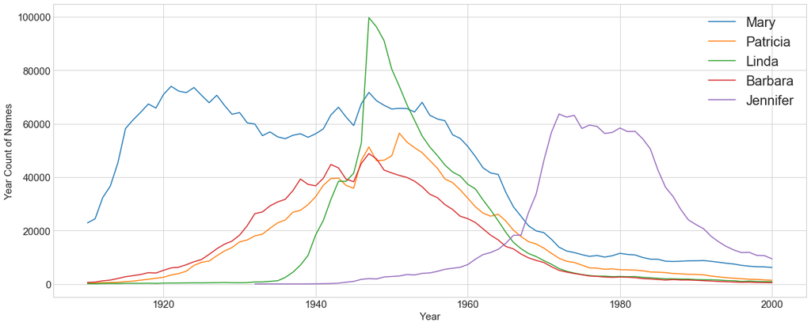

```python
%matplotlib inline
import matplotlib.pyplot as plt
plt.style.use('seaborn-whitegrid')
plt.rcParams['figure.figsize'] = [20, 8]
plt.xticks(fontsize=15)
plt.yticks(fontsize=15)

for name in female_name:
    df = female_frame[female_frame[3] == name]
    df = df.groupby([2]).sum()
    plt.plot(df.index.values, df[4], label=name)

# for name in male_name:
#     df = male_frame[male_frame[3] == name]
#     df = df.groupby([2]).sum()
#     plt.plot(df.index.values, df[4], label=name)

plt.legend(prop={'size': 20})
plt.xlabel('Year', fontsize=15)
plt.ylabel('Year Count of Names', fontsize=15)
```

```
Text(0,0.5,'Year Count of Names')
```

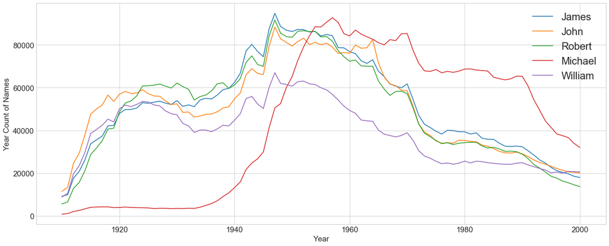

```python
%matplotlib inline
import matplotlib.pyplot as plt
plt.style.use('seaborn-whitegrid')
plt.rcParams['figure.figsize'] = [20, 8]
plt.xticks(fontsize=15)
plt.yticks(fontsize=15)

# for name in female_name:
#     df = female_frame[female_frame[3] == name]
#     df = df.groupby([2]).sum()
#     plt.plot(df.index.values, df[4], label=name)

for name in male_name:
    df = male_frame[male_frame[3] == name]
    df = df.groupby([2]).sum()
    plt.plot(df.index.values, df[4], label=name)

plt.legend(prop={'size': 20})
plt.xlabel('Year', fontsize=15)
plt.ylabel('Year Count of Names', fontsize=15)
```

I seperate diagrams into two categories: female and male. Both we can see a trend of increase, reaching the peak, and decrease.

   a. For the female name "Jennifer", its increase path is 20 years slower than others where we can assume that around 1970-1980, "Jennifer" becomes popular. The reason may due to certain famous star. Who knows! Anyway, it's interesting to find out.

   b. For the male name "Michael", there is an obvious small count during 1900-1940, where we can assume that people had no sense with "Michael" at that time, and after 1940, it gradually became popular.

It's worth mentioning that it's always better to combine history materials to give a more persuasive conclusion.

```
Text(0,0.5,'Year Count of Names')
```

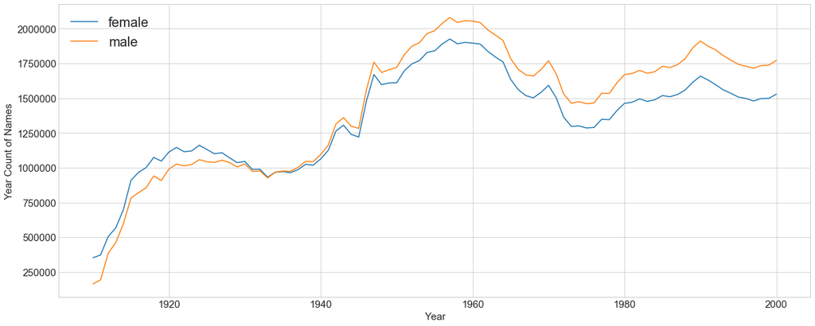

```python
%matplotlib inline
import matplotlib.pyplot as plt
plt.style.use('seaborn-whitegrid')
plt.rcParams['figure.figsize'] = [20, 8]
plt.xticks(fontsize=15)
plt.yticks(fontsize=15)


df = female_frame.groupby([2]).sum()
plt.plot(df.index.values, df[4], label="female")

df = male_frame.groupby([2]).sum()
plt.plot(df.index.values, df[4], label="male")

plt.legend(prop={'size': 20})
plt.xlabel('Year', fontsize=15)
plt.ylabel('Year Count of Names', fontsize=15)
```

## Problem 3

Well, people might wonder, what's the geographical distribution of these popular names. Other than looking at the data at a time perspective, it's also attractive to look at the data from space dimension. Just give a simple example below to show the geographical distribution of the most popular name "Mary" over all years. We can see that the darker colors are in the state of PA, NY, TX, IL, CA. It's probably because the population in those areas are more than other areas. In order to find out which zone prefers to use baby name "Mary", it's better for me to use the proportion data rather than absolute data. This is also an interesting topic to dig into.

Curious about more findings? Send the email to yl4089@columbia.edu.

See you there.

```python
import plotly
import plotly.plotly as py
plotly.tools.set_credentials_file(username='EthanLian', api_key='jWmA8Yp0T8bFgQG7juLX')
import pandas as pd

scl = [[0.0, 'rgb(242,240,247)'],[0.2, 'rgb(218,218,235)'],[0.4, 'rgb(188,189,220)'],\
            [0.6, 'rgb(158,154,200)'],[0.8, 'rgb(117,107,177)'],[1.0, 'rgb(84,39,143)']]

df = frame[frame[3] == "Mary"]
df = df.groupby([0]).sum()

data = [ dict(
        type='choropleth',
        colorscale = scl,
        autocolorscale = False,
        locations = df.index.values,
        z = df[4],
        locationmode = 'USA-states',
        #text = df['text'],
        marker = dict(
            line = dict (
                color = 'rgb(255,255,255)',
                width = 2
            ) ),
        colorbar = dict(
            title = "Mary Name Count")
        ) ]

layout = dict(
        title = 'What is the distribution of baby name Mary?',
        geo = dict(
            scope='usa',
            projection=dict( type='albers usa' ),
            showlakes = True,
            lakecolor = 'rgb(255, 255, 255)'),
             )

fig = dict( data=data, layout=layout )
py.iplot( fig, filename='d3-cloropleth-map' )
```

```
High five! You successfully sent some data to your account on plotly. View your plot in your browser at https://plot.ly/~EthanLian/0 or inside your plot.ly account where it is named 'd3-cloropleth-map'
```

[interactive chart not shown]